# Step 5: DADA2 Pipeline (Filtering, Denoising, Chimera Removal & Taxonomy Assignment)

# 1 Introduction

## 1.1 Purpose

This notebook is **Step 5** of the PacBio HiFi full-length 16S rRNA sequencing data processing pipeline. It implements the complete [DADA2](https://benjjneb.github.io/dada2/) workflow for single-end, full-length PacBio HiFi reads, with integrated reporting, checkpoints, taxonomy assignment, and portable exports.

## 1.2 Prerequisites

Before running this notebook, ensure that:

1. **Step 3 (Primer Trimming and Orientation)** has completed successfully.
2. Primer-trimmed FASTQ files are present in results/3_primer_trimming/primer_trimmed_reads/.
3. The Step 3 workbook primer_trimming_summary.xlsx is present and contains the sample-to-pool mapping.
4. **Recommended**: select and export `maxEE` with the Step 4 PacBio maxEE Parameter Explorer. If its workbook is absent, this notebook uses the documented fallback `maxEE = 2`.
5. Taxonomy training sets are available in tools/trainsets/ if taxonomy assignment is required. ASV inference still runs when those optional references are absent.

## 1.3 What This Notebook Does

The workflow accomplishes the following tasks:

1. **Read filtering**: Sequential removal of reads outside the expected full-length range, reads containing ambiguous bases (`N`), and reads exceeding the expected-error threshold, with losses tracked at each stage.
2. **Dereplication and learning error rates**: Consolidating identical sequences into unique reads and learning the PacBio HiFi error model with `PacBioErrfun`.
3. **Sample inference (denoising)**: Distinguishing true biological sequences from sequencing noise independently for each sample using `BAND_SIZE = 32`.
4. **Constructing the sequence table**: Combining the inferred full-length sequences directly; paired-read merging is neither required nor appropriate.
5. **Removing chimeras**: Identifying and discarding artificial recombinant sequences that can distort findings.
6. **Creating ASV tables**: Generating representative sequences and a sample-by-ASV count table.
7. **Assigning taxonomy**: Classifying ASVs with SILVA and/or GTDB when compatible reference files are installed.

## 1.4 Expected Input

- **Location**: results/3_primer_trimming/primer_trimmed_reads/
- **Naming convention**: `{SampleID}_primer_trimmed.fastq`
- **Format**: One uncompressed, single-end FASTQ file per sample
- **Sample identifiers**: `SampleID` does not contain `PoolNumber`; pool provenance is read from the Step 3 workbook.

## 1.5 Expected Output

- Filtered reads in results/5_dada2_pipeline/filtered_reads/
- DADA2 console logs in results/5_dada2_pipeline/console_output/
- Stage-specific checkpoints in results/5_dada2_pipeline/checkpoints/
- Read-quality profiles before and after filtering
- PacBio error-rate plot error_rates.pdf
- Amplicon-length plot amplicon_sequence_lengths.pdf
- Read tracking and workbook documentation in processing_summary.xlsx
- ASV representative sequences in asv_sequences.csv
- Sample-by-ASV counts in asv_count_table.csv
- Taxonomy tables in silva_taxonomy_table.csv and/or gtdb_taxonomy_table.csv, according to the selected references
- When more than one pool is present, matching per-pool tables are split into separate folders under results/5_dada2_pipeline/separate_pools/

# 2 Environment Setup

## 2.1 Load Required Packages

The chunk below loads every R package this notebook depends on, plus the shared helper functions used throughout the workflow for Excel writing, column documentation, and output links.

```r
# dada2: Core package for amplicon sequence variant inference.
library(dada2)

# Biostrings: Biological string manipulation used for ASV sequences.
library(Biostrings)

# data.table: High-performance data manipulation for summaries and exports.
library(data.table)

# DT: Interactive, horizontally scrollable tables in the HTML report.
library(DT)

# fs: Cross-platform filesystem operations.
library(fs)

# ggplot2: Publication-quality visualization of sequence lengths.
library(ggplot2)

# here: Reproducible paths relative to the project root.
library(here)

# openxlsx: Reading and writing Excel workbooks without Java.
library(openxlsx)

# parallel: CPU detection for multithreaded DADA2 operations.
library(parallel)

# ShortRead: Complete FASTQ record counting.
library(ShortRead)

# Source the workflow's shared Excel and reporting helpers.
source(here("R", "functions", "add_sheet_to_excel_function.R"))
source(here("R", "functions", "build_column_dictionary_function.R"))
source(here("R", "functions", "render_output_links_function.R"))
source(here("R", "functions", "render_output_tree_function.R"))

# Every HTML table uses the same fixed-height, horizontally scrollable layout.
# Sorting, searching, pagination, and the information footer are deliberately
# disabled so the report presents static audit tables without extra controls.
default_datatable_options <- list(
  scrollX = TRUE,
  scrollY = "400px",
  scrollCollapse = TRUE,
  paging = FALSE,
  searching = FALSE,
  ordering = FALSE,
  info = FALSE,
  dom = "t",
  autoWidth = TRUE,
  columnDefs = list(list(className = "dt-left", targets = "_all"))
)

safe_datatable <- function(data, options = list(), ...) {
  merged_options <- modifyList(default_datatable_options, options)
  tryCatch(
    DT::datatable(data, options = merged_options, rownames = FALSE, ...),
    error = function(e) {
      message("Interactive table display failed; showing a static table.")
      print(data)
    }
  )
}
```

# 3 Configuration

## 3.1 Define Path Parameters

Set up all the input and output paths for this step of the workflow.

```r
# Input folder containing the Q20-filtered, primer-trimmed, consistently
# oriented FASTQ files written by Step 3.
input_folder <- here("results", "3_primer_trimming", "primer_trimmed_reads")

# Step 3 workbook containing authoritative SampleID and PoolNumber metadata.
step3_workbook <- here(
  "results", "3_primer_trimming", "primer_trimming_summary.xlsx"
)

# Earlier workflow workbooks provide the raw-read and Q20-filtered counts used
# in the complete Reads_Tracking table.
step1_workbook <- here(
  "results", "1_data_integrity_and_sample_mapping",
  "data_integrity_and_sample_mapping.xlsx"
)
step2_workbook <- here(
  "results", "2_quality_filtered_reads",
  "quality_and_read_length_summary.xlsx"
)

# This notebook owns all files under results/5_dada2_pipeline/.
results_folder <- here("results")
output_folder <- here(results_folder, "5_dada2_pipeline")
filtered_reads_folder <- here(output_folder, "filtered_reads")
checkpoints_folder <- here(output_folder, "checkpoints")
console_output_folder <- here(output_folder, "console_output")

# Principal output files.
output_excel_path <- here(output_folder, "processing_summary.xlsx")

dir_create(output_folder, recurse = TRUE)
dir_create(filtered_reads_folder, recurse = TRUE)
dir_create(checkpoints_folder, recurse = TRUE)
dir_create(console_output_folder, recurse = TRUE)

cat("Input folder:", input_folder, "\n",
    "Output folder:", output_folder, "\n")
```

```
## Input folder: /Users/jon/Documents/DADA2_16S_PacBio_HiFi_Workflow/results/3_primer_trimming/primer_trimmed_reads
##  Output folder: /Users/jon/Documents/DADA2_16S_PacBio_HiFi_Workflow/results/5_dada2_pipeline
```

## 3.2 Configure DADA2 Parameters

PacBio HiFi reads are full-length, so `truncLen` is intentionally absent. The 1,000–1,600 bp interval follows the current PacBio HiFi-16S workflow default. This notebook loads `maxEE` from the Step 4 parameter workbook when available; otherwise it uses the clearly documented fallback `maxEE = 2`.

```r
# Retain primer-trimmed reads only when their full length falls within this
# interval. Unlike paired-end Illumina reads, PacBio HiFi reads already span
# the complete amplicon, so these values define a biological target-length
# filter rather than positions at which reads should be truncated.
minimum_read_length <- 1000L
maximum_read_length <- 1600L

# Use maxEE = 2 only as a fallback when Step 4 has not exported a selection.
# The active value and its source are resolved and validated immediately below.
fallback_maximum_expected_errors <- 2
step4_parameter_workbook <- here(
  "results", "4_dada2_parameter_selection", "dada2_filter_parameters.xlsx"
)

# "maxEE" means maximum expected errors. For each base, its quality score Q is
# converted to an error probability P using P = 10^(-Q/10); DADA2 then sums
# those probabilities across the complete read. A read is discarded when that
# sum exceeds maxEE. Values below 1 are very stringent, values around 1--2 are
# moderate, and values above 2 are progressively less stringent. This filter
# complements Step 2's mean-Q20 filter because it accounts for the accumulated
# error probability across each full-length read.
maximum_expected_errors <- fallback_maximum_expected_errors
maximum_expected_errors_source <- "Step 5 fallback"

# Load exactly one numeric max_expected_errors row from the Step 4 workbook.
# Failing clearly on a malformed workbook prevents a stale or ambiguous value
# from being applied silently.
if (file_exists(step4_parameter_workbook)) {
  workbook_sheets <- openxlsx::getSheetNames(step4_parameter_workbook)
  if (!("Parameters" %in% workbook_sheets)) {
    stop("The Step 4 parameter workbook has no Parameters sheet: ",
         step4_parameter_workbook)
  }
  step4_parameters <- openxlsx::read.xlsx(
    step4_parameter_workbook,
    sheet = "Parameters"
  )
  if (!all(c("Parameter", "Value") %in% names(step4_parameters))) {
    stop("The Step 4 Parameters sheet must contain Parameter and Value columns: ",
         step4_parameter_workbook)
  }
  selected_row <- which(
    trimws(as.character(step4_parameters$Parameter)) == "max_expected_errors"
  )
  if (length(selected_row) != 1L) {
    stop("The Step 4 Parameters sheet must contain exactly one max_expected_errors row: ",
         step4_parameter_workbook)
  }
  selected_value <- suppressWarnings(as.numeric(step4_parameters$Value[[selected_row]]))
  if (length(selected_value) != 1L || !is.finite(selected_value) || selected_value <= 0) {
    stop("Step 4 max_expected_errors must be one finite numeric value greater than zero: ",
         step4_parameter_workbook)
  }
  maximum_expected_errors <- selected_value
  maximum_expected_errors_source <- "Step 4 parameter workbook"
}

# Full-length reads must not be truncated by position or base quality.
# `minQ = 0` disables rejection based on the lowest individual base quality,
# while `truncQ = 0` prevents truncation at low-quality bases. `maxN = 0`
# rejects every read containing an ambiguous nucleotide (N), as required for
# downstream DADA2 sample inference.
minimum_base_quality <- 0L
truncation_quality <- 0L
maximum_ambiguous_bases <- 0L

# `BAND_SIZE` controls the width of the band used by DADA2's sequence
# alignment. The wider value of 32 is appropriate for PacBio HiFi reads and is
# retained from the original dada2_PacBio.R implementation.
band_size <- 32L

# `MAX_CONSIST` is the maximum number of self-consistency iterations used while
# learning the error model. If convergence is not reached within this number,
# DADA2 returns the error rates estimated in the final iteration.
maximum_consistency_iterations <- 25L

# `nbases` is the minimum number of bases DADA2 attempts to use for error-rate
# learning. Samples are read until this total is reached or all supplied reads
# have been used.
error_learning_bases <- 1e10

# `pool = FALSE` infers ASVs independently in every sample. For extremely
# diverse communities, `pool = TRUE` can increase sensitivity to rare ASVs by
# processing all samples together, while `pool = "pseudo"` performs an initial
# independent pass and then shares detected variants across samples. This
# workflow retains the Illumina workflow's independent-sample setting.
pooling_method <- FALSE

# With `method = "consensus"`, each sample is checked independently for
# bimeras and the sample-level evidence is combined into a consensus decision
# for each ASV in the sequence table.
chimera_method <- "consensus"

# A candidate chimera's parent sequences must be at least this many times more
# abundant than the candidate before it can be removed. The PacBio workflow
# uses 3.5, retained from the original dada2_PacBio.R implementation.
minimum_parent_fold <- 3.5

parameter_table <- data.frame(
  Parameter = c(
    "minimum_read_length", "maximum_read_length", "maximum_expected_errors",
    "minimum_base_quality", "truncation_quality", "maximum_ambiguous_bases",
    "band_size", "maximum_consistency_iterations", "error_learning_bases",
    "pooling_method", "chimera_method", "minimum_parent_fold"
  ),
  NumericValue = c(
    minimum_read_length, maximum_read_length, maximum_expected_errors,
    minimum_base_quality, truncation_quality, maximum_ambiguous_bases,
    band_size, maximum_consistency_iterations, error_learning_bases,
    NA_real_, NA_real_, minimum_parent_fold
  ),
  TextValue = c(
    rep(NA_character_, 9), pooling_method, chimera_method, NA_character_
  ),
  Source = c(
    "Step 5 fixed", "Step 5 fixed", maximum_expected_errors_source,
    rep("Step 5 fixed", 9)
  ),
  stringsAsFactors = FALSE
)
```

Review the active values below before filtering. In particular, confirm the target-length interval and whether `maxEE` came from Step 4 or the documented fallback.

| Parameter | NumericValue | TextValue | Source |
| --- | --- | --- | --- |
| minimum_read_length | 1000 |  | Step 5 fixed |
| maximum_read_length | 1600 |  | Step 5 fixed |
| maximum_expected_errors | 2 |  | Step 4 parameter workbook |
| minimum_base_quality | 0 |  | Step 5 fixed |
| truncation_quality | 0 |  | Step 5 fixed |
| maximum_ambiguous_bases | 0 |  | Step 5 fixed |
| band_size | 32 |  | Step 5 fixed |
| maximum_consistency_iterations | 25 |  | Step 5 fixed |
| error_learning_bases | 10000000000 |  | Step 5 fixed |
| pooling_method |  | FALSE | Step 5 fixed |

[output cut: 2 more lines]

## 3.3 Define Processing Parameters

Configure parallel processing and reproducibility while reserving two CPU cores for normal system activity.

```r
detected_cores <- suppressWarnings(detectCores())
available_cores <- if (
  length(detected_cores) == 1L && is.finite(detected_cores) && detected_cores >= 1
) as.integer(detected_cores) else 1L
nr_threads <- max(1L, available_cores - 2L)

set.seed(42)

cat("Available CPU cores:", available_cores, "\n",
    "Threads for DADA2:", nr_threads, "\n",
    "Random seed: 42\n")
```

```
## Available CPU cores: 12
##  Threads for DADA2: 10
##  Random seed: 42
```

## 3.4 Define Taxonomy Database Selection

Use the workflow’s SILVA/GTDB reference-database layout. Both databases are selected when both complete reference pairs are installed; one is selected when only one is complete; taxonomy is skipped when neither is available.

```r
trainsets_folder <- here("tools", "trainsets")

find_reference <- function(folder, pattern) {
  matches <- list.files(folder, pattern = pattern, ignore.case = TRUE, full.names = TRUE)
  if (length(matches)) matches[[1L]] else NA_character_
}

database_config <- list(
  SILVA = list(
    trainset = find_reference(here(trainsets_folder, "SILVA"), "genus.*\\.fa(\\.gz)?$"),
    species = find_reference(here(trainsets_folder, "SILVA"), "species.*\\.fa(\\.gz)?$")
  ),
  GTDB = list(
    trainset = find_reference(here(trainsets_folder, "GTDB"), "genus.*\\.fa(\\.gz)?$"),
    species = find_reference(here(trainsets_folder, "GTDB"), "species.*\\.fa(\\.gz)?$")
  )
)

database_ready <- vapply(database_config, function(x) {
  all(vapply(x, function(path) length(path) == 1L && !is.na(path) && file_exists(path), logical(1)))
}, logical(1))
databases_to_use <- names(database_ready)[database_ready]
taxonomy_database <- if (length(databases_to_use) == 2L) {
  "BOTH"
} else if (length(databases_to_use) == 1L) {
  databases_to_use
} else {
  "NONE"
}

cat("Taxonomy database mode:", taxonomy_database, "\n")
```

```
## Taxonomy database mode: BOTH
```

If no complete reference pair is available, the report explains why taxonomy is being skipped while allowing ASV inference to continue.

# 4 Discover Input Files

## 4.1 Read FASTQ Files

Scan the Step 3 folder for one single-end full-length FASTQ per sample and validate the identifiers against Step 3’s `Sample_Summary` sheet.

```r
if (!dir_exists(input_folder)) {
  stop("Primer-trimmed input folder not found: ", input_folder, "\nRun Step 3 first.")
}
if (!file_exists(step3_workbook)) {
  stop("Step 3 workbook not found: ", step3_workbook)
}
if (!file_exists(step1_workbook)) {
  stop("Step 1 workbook not found: ", step1_workbook)
}
if (!file_exists(step2_workbook)) {
  stop("Step 2 workbook not found: ", step2_workbook)
}

input_pattern <- "(?i)_primer_trimmed\\.(fastq|fq)$"
input_paths <- sort(dir_ls(input_folder, regexp = input_pattern, type = "file"))
sample_names <- sub(input_pattern, "", path_file(input_paths), perl = TRUE)

if (length(input_paths) == 0L) stop("No primer-trimmed FASTQ files were found.")
if (anyDuplicated(sample_names)) stop("Primer-trimmed FASTQs produce duplicate SampleIDs.")
if (any(file_size(input_paths) == 0)) stop("One or more primer-trimmed FASTQs are empty.")

step3_samples <- as.data.table(read.xlsx(step3_workbook, sheet = "Sample_Summary"))
required_step3_columns <- c("PoolNumber", "SampleID")
if (!all(required_step3_columns %in% names(step3_samples))) {
  stop("Step 3 Sample_Summary must contain PoolNumber and SampleID.")
}
step3_samples <- unique(step3_samples[, .(
  PoolNumber = as.integer(PoolNumber),
  SampleID = as.character(SampleID)
)])
if (anyDuplicated(step3_samples$SampleID)) stop("Step 3 contains duplicate SampleIDs.")
if (!setequal(sample_names, step3_samples$SampleID)) {
  stop("Step 3 FASTQ filenames and Sample_Summary identifiers do not match exactly.")
}
step3_samples <- step3_samples[match(sample_names, SampleID)]

# Read counts from Steps 1-3 are joined by SampleID rather than by row order.
# This preserves explicit sample-alignment checks across all upstream stages,
# including the PacBio-specific Q20 stage.
step1_samples <- as.data.table(read.xlsx(step1_workbook, sheet = "Sample_Manifest"))
step2_samples <- as.data.table(read.xlsx(step2_workbook, sheet = "Sample_QC"))
step3_tracking <- as.data.table(read.xlsx(step3_workbook, sheet = "Sample_Summary"))

required_step1_columns <- c("SampleID", "InputReads")
required_step2_columns <- c("SampleID", "PassingReads")
required_step3_tracking_columns <- c("SampleID", "RetainedReads")

if (!all(required_step1_columns %in% names(step1_samples))) {
  stop("Step 1 Sample_Manifest must contain SampleID and InputReads.")
}
if (!all(required_step2_columns %in% names(step2_samples))) {
  stop("Step 2 Sample_QC must contain SampleID and PassingReads.")
}
if (!all(required_step3_tracking_columns %in% names(step3_tracking))) {
  stop("Step 3 Sample_Summary must contain SampleID and RetainedReads.")
}
if (!setequal(sample_names, step1_samples$SampleID) ||
    !setequal(sample_names, step2_samples$SampleID) ||
    !setequal(sample_names, step3_tracking$SampleID)) {
  stop("Sample identifiers are inconsistent across the Step 1, Step 2, and Step 3 workbooks.")
}

step1_samples <- step1_samples[match(sample_names, SampleID)]
step2_samples <- step2_samples[match(sample_names, SampleID)]
step3_tracking <- step3_tracking[match(sample_names, SampleID)]

sample_table <- data.frame(
  PoolNumber = step3_samples$PoolNumber,
  SampleID = sample_names,
  InputFASTQ = path_file(input_paths),
  InputSizeMB = round(as.numeric(file_size(input_paths)) / 1024^2, 3),
  stringsAsFactors = FALSE
)

cat("Samples found:", length(sample_names), "\n")
```

```
## Samples found: 6
```

The validated sample inventory below confirms the stable `SampleID`, pool assignment, input filename, and file size entering DADA2.

| PoolNumber | SampleID | InputFASTQ | InputSizeMB |
| --- | --- | --- | --- |
| 1 | Sample01 | Sample01_primer_trimmed.fastq | 3.063 |
| 1 | Sample02 | Sample02_primer_trimmed.fastq | 4.356 |
| 1 | Sample03 | Sample03_primer_trimmed.fastq | 4.487 |
| 2 | Sample04 | Sample04_primer_trimmed.fastq | 1.483 |
| 2 | Sample05 | Sample05_primer_trimmed.fastq | 1.337 |
| 2 | Sample06 | Sample06_primer_trimmed.fastq | 1.573 |

## 4.2 Define Checkpoint Signature

Build a strict signature from input checksums, parameters, references, and the DADA2 version. A checkpoint is reused only when every relevant value is identical.

```r
selected_reference_paths <- if (length(databases_to_use)) {
  unname(unlist(database_config[databases_to_use]))
} else character()

pipeline_signature <- list(
  input_paths = path_norm(input_paths),
  input_md5 = unname(tools::md5sum(input_paths)),
  parameters = parameter_table,
  taxonomy_mode = taxonomy_database,
  reference_paths = selected_reference_paths,
  reference_md5 = if (length(selected_reference_paths)) {
    unname(tools::md5sum(selected_reference_paths))
  } else character(),
  dada2_version = as.character(packageVersion("dada2"))
)

checkpoint_path <- function(stage) {
  here(checkpoints_folder, paste0("checkpoint_", stage, ".rds"))
}

load_stage_checkpoint <- function(stage, required_objects) {
  checkpoint_file <- checkpoint_path(stage)
  if (!file_exists(checkpoint_file)) return(NULL)
  checkpoint <- tryCatch(readRDS(checkpoint_file), error = function(e) NULL)
  if (is.null(checkpoint) ||
      !identical(checkpoint$signature, pipeline_signature) ||
      !identical(checkpoint$stage, stage) ||
      !all(required_objects %in% names(checkpoint$objects))) return(NULL)
  message("Resuming from validated checkpoint: ", path_file(checkpoint_file))
  checkpoint$objects
}

save_stage_checkpoint <- function(stage, objects) {
  checkpoint_file <- checkpoint_path(stage)
  temporary_file <- paste0(checkpoint_file, ".tmp")
  saveRDS(
    list(stage = stage, signature = pipeline_signature, objects = objects),
    temporary_file,
    compress = TRUE
  )
  if (file_exists(checkpoint_file)) file_delete(checkpoint_file)
  file_move(temporary_file, checkpoint_file)
  checkpoint_file
}
```

# 5 Quality Filtering

## 5.1 Inspect Read Quality Profiles Before Filtering

The quality profile shows the distribution of base qualities as a function of sequence position. There is one full-length read stream per PacBio sample. The PDF contains the aggregated overview first, followed by one plot per sample.

```r
quality_before_path <- here(output_folder, "QC_before_filtering.pdf")
quality_before_plots <- list()

# Write the aggregated quality-profile overview first.
aggregated_before_plot <- tryCatch(
  plotQualityProfile(input_paths, aggregate = TRUE),
  error = function(e) {
    warning("Could not create the aggregated pre-filter quality profile: ",
            conditionMessage(e), call. = FALSE)
    NULL
  }
)
if (!is.null(aggregated_before_plot)) {
  quality_before_plots[["aggregated"]] <- aggregated_before_plot
}

# Generate the individual sample plots after the aggregate overview.
for (i in seq_along(input_paths)) {
  plot_object <- tryCatch(
    plotQualityProfile(input_paths[[i]]) + ggtitle(sample_names[[i]]),
    error = function(e) NULL
  )
  if (!is.null(plot_object)) quality_before_plots[[sample_names[[i]]]] <- plot_object
}

pdf(quality_before_path, width = 11, height = 8.5, onefile = TRUE)
for (plot_object in quality_before_plots) print(plot_object)
dev.off()
```

The complete quality-profile PDF is linked below; it begins with the aggregated view and then shows every sample separately.

- Quality profiles before filtering (PDF): results/5_dada2_pipeline/QC_before_filtering.pdf

## 5.2 Execute Filtering

Apply three explicit single-end filtering stages so losses from length, ambiguous bases, and expected errors remain separately auditable. No positional truncation is performed and every output FASTQ remains uncompressed.

```r
# Clear only the managed final FASTQs before rebuilding this run. Temporary
# stage folders are isolated below and removed after the final filter succeeds.
stale_filtered <- dir_ls(
  filtered_reads_folder,
  regexp = "\\.(fastq|fq)$",
  type = "file",
  fail = FALSE
)
if (length(stale_filtered)) file_delete(stale_filtered)

filter_staging <- here(output_folder, ".filter_staging")
if (dir_exists(filter_staging)) dir_delete(filter_staging)
length_stage_folder <- here(filter_staging, "length")
n_stage_folder <- here(filter_staging, "no_N")
dir_create(length_stage_folder, recurse = TRUE)
dir_create(n_stage_folder, recurse = TRUE)

length_stage_paths <- here(length_stage_folder, paste0(sample_names, ".fastq"))
n_stage_paths <- here(n_stage_folder, paste0(sample_names, ".fastq"))
filtered_paths <- here(filtered_reads_folder, paste0(sample_names, "_filtered.fastq"))

# Stage 1 retains only the expected full-length interval. maxN and maxEE are
# unrestricted here so this row measures length loss alone.
length_counts <- filterAndTrim(
  fwd = input_paths,
  filt = length_stage_paths,
  truncLen = 0,
  minLen = minimum_read_length,
  maxLen = maximum_read_length,
  maxN = Inf,
  maxEE = Inf,
  truncQ = 0,
  minQ = 0,
  rm.phix = FALSE,
  compress = FALSE,
  multithread = nr_threads,
  verbose = TRUE
)

# Stage 2 rejects ambiguous bases without imposing additional quality or
# length thresholds.
n_counts <- filterAndTrim(
  fwd = length_stage_paths,
  filt = n_stage_paths,
  truncLen = 0,
  minLen = 1,
  maxLen = Inf,
  maxN = maximum_ambiguous_bases,
  maxEE = Inf,
  truncQ = 0,
  minQ = 0,
  rm.phix = FALSE,
  compress = FALSE,
  multithread = nr_threads,
  verbose = TRUE
)

# Stage 3 applies the expected-error threshold and PhiX removal. truncLen,
# truncQ, and minQ remain disabled to preserve the complete PacBio amplicon.
quality_counts <- filterAndTrim(
  fwd = n_stage_paths,
  filt = filtered_paths,
  truncLen = 0,
  minLen = 1,
  maxLen = Inf,
  maxN = maximum_ambiguous_bases,
  maxEE = maximum_expected_errors,
  truncQ = truncation_quality,
  minQ = minimum_base_quality,
  rm.phix = TRUE,
  compress = FALSE,
  multithread = nr_threads,
  verbose = TRUE
)

rownames(length_counts) <- sample_names
rownames(n_counts) <- sample_names
rownames(quality_counts) <- sample_names

filtering_summary <- data.frame(
  PoolNumber = step3_samples$PoolNumber,
  SampleID = sample_names,
  InputReads = as.numeric(length_counts[, "reads.in"]),
  AfterLengthFilter = as.numeric(length_counts[, "reads.out"]),
  AfterNFilter = as.numeric(n_counts[, "reads.out"]),
  AfterExpectedErrorFilter = as.numeric(quality_counts[, "reads.out"]),
  PercentRetained = round(
    100 * as.numeric(quality_counts[, "reads.out"]) /
      as.numeric(length_counts[, "reads.in"]),
    2
  ),
  stringsAsFactors = FALSE
)

if (any(filtering_summary$AfterExpectedErrorFilter == 0L)) {
  stop("At least one sample retained no reads after DADA2 filtering.")
}
if (dir_exists(filter_staging)) dir_delete(filter_staging)
```

The table below makes losses at the target-length, ambiguous-base, and expected-error stages visible separately for every sample.

| PoolNumber | SampleID | InputReads | AfterLengthFilter | AfterNFilter | AfterExpectedErrorFilter | PercentRetained |
| --- | --- | --- | --- | --- | --- | --- |
| 1 | Sample01 | 1092 | 1092 | 1092 | 887 | 81.23 |
| 1 | Sample02 | 1554 | 1553 | 1553 | 1388 | 89.32 |
| 1 | Sample03 | 1600 | 1600 | 1600 | 1425 | 89.06 |
| 2 | Sample04 | 528 | 527 | 527 | 454 | 85.98 |
| 2 | Sample05 | 479 | 479 | 479 | 433 | 90.4 |
| 2 | Sample06 | 564 | 564 | 564 | 510 | 90.43 |

## 5.3 Quality Profiles After Filtering

Generate the same quality diagnostic for the reads entering PacBio error learning and denoising.

```r
names(filtered_paths) <- sample_names
quality_after_path <- here(output_folder, "QC_after_filtering.pdf")
quality_after_plots <- list()

# Write the aggregated quality-profile overview first.
aggregated_after_plot <- tryCatch(
  plotQualityProfile(filtered_paths, aggregate = TRUE),
  error = function(e) {
    warning("Could not create the aggregated post-filter quality profile: ",
            conditionMessage(e), call. = FALSE)
    NULL
  }
)
if (!is.null(aggregated_after_plot)) {
  quality_after_plots[["aggregated"]] <- aggregated_after_plot
}

# Generate the individual sample plots after the aggregate overview.
for (i in seq_along(filtered_paths)) {
  plot_object <- tryCatch(
    plotQualityProfile(filtered_paths[[i]]) + ggtitle(sample_names[[i]]),
    error = function(e) NULL
  )
  if (!is.null(plot_object)) quality_after_plots[[sample_names[[i]]]] <- plot_object
}

pdf(quality_after_path, width = 11, height = 8.5, onefile = TRUE)
for (plot_object in quality_after_plots) print(plot_object)
dev.off()
```

Open the linked PDF to inspect the quality distributions of the reads that actually enter error learning and denoising.

- Quality profiles after filtering (PDF): results/5_dada2_pipeline/QC_after_filtering.pdf

# 6 Learning Error Rates

## 6.1 Learn the PacBio Error Model

Learn one error model for the consistently oriented full-length reads. `PacBioErrfun`, `BAND_SIZE = 32`, and `MAX_CONSIST = 25` configure error learning for PacBio HiFi reads.

```r
error_log <- here(console_output_folder, "dada2_error_model.log")
error_log_connection <- file(error_log, open = "wt")
sink(error_log_connection, split = TRUE)

tryCatch({
  cat("Learning error rates for PacBio HiFi reads...\n",
      "This step may take several minutes.\n\n")
  error_rates <- withCallingHandlers({
    learnErrors(
      # Paths to the quality-filtered, full-length PacBio FASTQ files.
      filtered_paths,
      # Use DADA2's PacBio-specific error-estimation function instead of the
      # default Illumina error model.
      errorEstimationFunction = PacBioErrfun,
      # Read samples until at least this many bases have been examined, or all
      # supplied reads have been used.
      nbases = error_learning_bases,
      # Randomize sample/read selection rather than always learning from files
      # in their supplied order.
      randomize = TRUE,
      # Use the wider PacBio alignment band configured above.
      BAND_SIZE = band_size,
      # Use the configured CPU threads for error learning.
      multithread = nr_threads,
      # Print the self-consistency progress to the console log.
      verbose = TRUE,
      # Stop after this many self-consistency iterations if the model has not
      # converged earlier.
      MAX_CONSIST = maximum_consistency_iterations
    )
  }, message = function(m) {
    cat(conditionMessage(m), "\n", sep = "")
    invokeRestart("muffleMessage")
  })
  cat("\nPacBio error model learned.\n")
}, finally = {
  sink()
  close(error_log_connection)
})
```

```
## Learning error rates for PacBio HiFi reads...
##  This step may take several minutes.
##
## 7412408 total bases in 5097 reads from 6 samples will be used for learning the error rates.
## Initializing error rates to maximum possible estimate.
## selfConsist step 1 ......
##    selfConsist step 2
##    selfConsist step 3
##    selfConsist step 4
##    selfConsist step 5
## Convergence after  5  rounds.
##
## PacBio error model learned.
```

The validated error model and its filtering context are saved as a reusable checkpoint for an identical input-and-parameter signature.

The following links provide the error-model plot, full console log, and signature-validated checkpoint generated by this stage.

- PacBio error-rate plot (PDF): results/5_dada2_pipeline/error_rates.pdf
- Error-learning console log (text): results/5_dada2_pipeline/console_output/dada2_error_model.log
- Error-model checkpoint (RDS): results/5_dada2_pipeline/checkpoints/checkpoint_error_model.rds

# 7 Sample Inference (Denoising)

## 7.1 Dereplicate and Denoise Reads

Dereplicate identical reads, then infer ASVs independently for each sample with the learned PacBio error model. The `pool = FALSE` setting keeps sample inference independent rather than pooled or pseudo-pooled.

```r
dereplicated_sequences <- derepFastq(filtered_paths, verbose = TRUE)
```

```
## Dereplicating sequence entries in Fastq file: /Users/jon/Documents/DADA2_16S_PacBio_HiFi_Workflow/results/5_dada2_pipeline/filtered_reads/Sample01_filtered.fastq
```

```
## Encountered 776 unique sequences from 887 total sequences read.
```

```
## Dereplicating sequence entries in Fastq file: /Users/jon/Documents/DADA2_16S_PacBio_HiFi_Workflow/results/5_dada2_pipeline/filtered_reads/Sample02_filtered.fastq
```

```
## Encountered 772 unique sequences from 1388 total sequences read.
```

```
## Dereplicating sequence entries in Fastq file: /Users/jon/Documents/DADA2_16S_PacBio_HiFi_Workflow/results/5_dada2_pipeline/filtered_reads/Sample03_filtered.fastq
```

```
## Encountered 745 unique sequences from 1425 total sequences read.
```

```
## Dereplicating sequence entries in Fastq file: /Users/jon/Documents/DADA2_16S_PacBio_HiFi_Workflow/results/5_dada2_pipeline/filtered_reads/Sample04_filtered.fastq
```

```
## Encountered 334 unique sequences from 454 total sequences read.
```

```
## Dereplicating sequence entries in Fastq file: /Users/jon/Documents/DADA2_16S_PacBio_HiFi_Workflow/results/5_dada2_pipeline/filtered_reads/Sample05_filtered.fastq
```

```
## Encountered 302 unique sequences from 433 total sequences read.
```

```
## Dereplicating sequence entries in Fastq file: /Users/jon/Documents/DADA2_16S_PacBio_HiFi_Workflow/results/5_dada2_pipeline/filtered_reads/Sample06_filtered.fastq
```

```
## Encountered 407 unique sequences from 510 total sequences read.
```

```r
names(dereplicated_sequences) <- sample_names

denoise_log <- here(console_output_folder, "dada2_denoise.log")
denoise_log_connection <- file(denoise_log, open = "wt")
sink(denoise_log_connection, split = TRUE)

tryCatch({
  cat(">> Denoising PacBio HiFi reads\n")
  cat("   Using", nr_threads, "threads for parallel processing\n\n")
  denoised_sequences <- withCallingHandlers({
    dada(
      # Dereplicated full-length reads for every sample.
      dereplicated_sequences,
      # PacBio error rates learned from this dataset in the preceding stage.
      err = error_rates,
      # Use the PacBio alignment-band width configured above.
      BAND_SIZE = band_size,
      # Use the configured CPU threads for sample inference.
      multithread = nr_threads,
      # FALSE processes samples independently; TRUE pools all samples and
      # "pseudo" performs pseudo-pooling.
      pool = pooling_method,
      # Print sample-inference progress to the console log.
      verbose = TRUE
    )
  }, message = function(m) {
    cat(conditionMessage(m), "\n", sep = "")
    invokeRestart("muffleMessage")
  })
  cat("\nDenoising summary:\n")
  print(denoised_sequences)
  cat("\nSample inference complete.\n")
}, finally = {
  sink()
  close(denoise_log_connection)
})
```

```
## >> Denoising PacBio HiFi reads
##    Using 10 threads for parallel processing
##
## Sample 1 - 887 reads in 776 unique sequences.
## Sample 2 - 1388 reads in 772 unique sequences.
## Sample 3 - 1425 reads in 745 unique sequences.
## Sample 4 - 454 reads in 334 unique sequences.
## Sample 5 - 433 reads in 302 unique sequences.
## Sample 6 - 510 reads in 407 unique sequences.
##
## Denoising summary:
## $Sample01
## dada-class: object describing DADA2 denoising results
## 15 sequence variants were inferred from 776 input unique sequences.
## Key parameters: OMEGA_A = 1e-40, OMEGA_C = 1e-40, BAND_SIZE = 32
##
## $Sample02
## dada-class: object describing DADA2 denoising results
## 39 sequence variants were inferred from 772 input unique sequences.
## Key parameters: OMEGA_A = 1e-40, OMEGA_C = 1e-40, BAND_SIZE = 32
##
## $Sample03
## dada-class: object describing DADA2 denoising results
## 47 sequence variants were inferred from 745 input unique sequences.
## Key parameters: OMEGA_A = 1e-40, OMEGA_C = 1e-40, BAND_SIZE = 32
##
## $Sample04
## dada-class: object describing DADA2 denoising results
## 14 sequence variants were inferred from 334 input unique sequences.
## Key parameters: OMEGA_A = 1e-40, OMEGA_C = 1e-40, BAND_SIZE = 32
##
## $Sample05
## dada-class: object describing DADA2 denoising results
## 20 sequence variants were inferred from 302 input unique sequences.
## Key parameters: OMEGA_A = 1e-40, OMEGA_C = 1e-40, BAND_SIZE = 32
##
## $Sample06
## dada-class: object describing DADA2 denoising results
## 19 sequence variants were inferred from 407 input unique sequences.
## Key parameters: OMEGA_A = 1e-40, OMEGA_C = 1e-40, BAND_SIZE = 32
##
##
## Sample inference complete.
```

After denoising completes, the inferred sample objects and their provenance are checkpointed and linked with the complete console log.

- Denoising console log (text): results/5_dada2_pipeline/console_output/dada2_denoise.log
- Denoising checkpoint (RDS): results/5_dada2_pipeline/checkpoints/checkpoint_denoised.rds

# 8 Construct Sequence Table

## 8.1 Construct and Inspect the Sequence Table

Construct the sample-by-sequence table directly from the denoised full-length reads. There is no paired-read merge stage for PacBio HiFi.

```r
sequence_table <- makeSequenceTable(denoised_sequences)

# Confirm that the full-length filter remains satisfied after ASV inference.
sequence_lengths <- nchar(colnames(sequence_table))
target_length_mask <- sequence_lengths >= minimum_read_length &
  sequence_lengths <= maximum_read_length
target_length_sequence_table <- sequence_table[, target_length_mask, drop = FALSE]
target_length_filtered_reads_per_sample <- rowSums(target_length_sequence_table)

# Get sequence length distribution
sequence_length_df <- as.data.frame(table(sequence_lengths))
colnames(sequence_length_df) <- c("Length", "Count")
sequence_length_df$Length <- as.integer(as.character(sequence_length_df$Length))

# Total number of amplicon sequence variants (ASVs) represented in the
# histogram below, i.e. the number of unique sequences in sequence_table
# before the length filter further down this notebook is applied
total_sequence_variants <- sum(sequence_length_df$Count)

# Number (and percentage) of those ASVs whose length falls inside the target
# amplicon range, i.e. the ASVs the length filter will retain
sequence_variants_in_target_range <- sum(
  sequence_length_df$Count[
    sequence_length_df$Length >= minimum_read_length &
      sequence_length_df$Length <= maximum_read_length
  ]
)
pct_sequence_variants_in_target_range <- round(
  100 * sequence_variants_in_target_range / total_sequence_variants, 1
)

# Headroom above the tallest bar so the summary annotation below is not
# clipped by the plot panel
histogram_y_max <- max(sequence_length_df$Count)

# Visualize the amplicon length distribution with a histogram, built from
# the full (pre-filter) sequence table so off-target lengths remain visible.
# Publication-ready styling: white panel with light horizontal gridlines only
# (theme_classic base), bold serif-free axis titles, and the two target-length
# threshold lines identified directly via their own x-axis tick labels (in the
# same firebrick red as the lines) rather than separate floating text
# annotations, so the coordinates read unambiguously as axis values.
length_plot <- ggplot(sequence_length_df, aes(x = Length, y = Count)) +
  geom_bar(stat = "identity", fill = "#123C69", width = 0.9) +
  # Vertical reference lines marking the minimum and maximum target
  # amplicon lengths
  geom_vline(xintercept = minimum_read_length, linetype = "dashed", colour = "firebrick3", linewidth = 0.6) +
  geom_vline(xintercept = maximum_read_length, linetype = "dashed", colour = "firebrick3", linewidth = 0.6) +
  # Summary annotation reporting the total number of ASVs represented in
  # the histogram and how many of them fall inside the target amplicon
  # length range.
  annotate("label", x = Inf, y = Inf,
           label = paste0(
             "Total sequences: ", total_sequence_variants, "\n",
             "Within ", minimum_read_length, "-", maximum_read_length, " bp: ",
             sequence_variants_in_target_range,
             " (", pct_sequence_variants_in_target_range, "%)"
           ),
           hjust = 1, vjust = 1, size = 3.2, colour = "black",
           fill = "white", label.size = 0.3) +
  scale_x_continuous(
    breaks = c(minimum_read_length, maximum_read_length),
    labels = paste0(c(minimum_read_length, maximum_read_length), " bp")
  ) +
  scale_y_continuous(expand = expansion(mult = c(0, 0.05))) +
  labs(x = "Sequence Length (bp)", y = "Frequency",
       title = "Amplicon Length Distribution") +
  coord_cartesian(ylim = c(0, histogram_y_max * 1.18)) +
  theme_classic(base_size = 12) +
  theme(
    plot.title = element_text(hjust = 0.5, face = "bold", size = 13),
    axis.title = element_text(face = "bold", size = 11),
    axis.text.x = element_text(colour = "firebrick3", face = "bold", size = 10),
    axis.text.y = element_text(colour = "black", size = 10),
    axis.line = element_line(colour = "black", linewidth = 0.4),
    axis.ticks = element_line(colour = "black", linewidth = 0.4),
    panel.grid.major.y = element_line(colour = "grey85", linewidth = 0.3),
    panel.grid.minor = element_blank()
  )
```

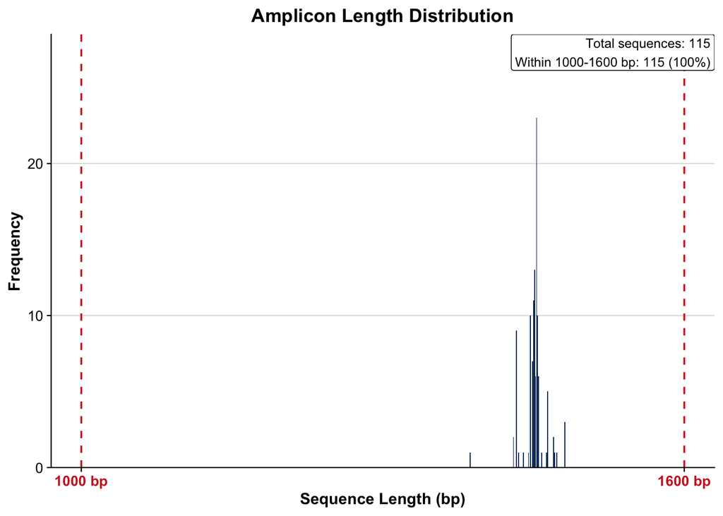

- Amplicon sequence lengths (PDF): results/5_dada2_pipeline/amplicon_sequence_lengths.pdf

# 9 Removing Chimeras

## 9.1 Remove Chimeric Sequences

Remove chimeras from the length-confirmed sequence table with the consensus method. The abundance requirement from the original PacBio script is retained.

```r
chimera_log <- here(console_output_folder, "dada2_remove_chimeras.log")
chimera_log_connection <- file(chimera_log, open = "wt")
sink(chimera_log_connection, split = TRUE)

tryCatch({
  cat("Removing chimeric sequences...\n\n")
  non_chimeric_table <- withCallingHandlers({
    removeBimeraDenovo(
      # Sequence table after the target-length filter.
      target_length_sequence_table,
      # Check samples independently and combine their calls into a consensus
      # chimera decision for every ASV.
      method = chimera_method,
      # Require potential parents to exceed the candidate's abundance by this
      # factor before identifying the candidate as a chimera.
      minFoldParentOverAbundance = minimum_parent_fold,
      # Use the configured CPU threads for chimera detection.
      multithread = nr_threads,
      # Print chimera-removal progress to the console log.
      verbose = TRUE
    )
  }, message = function(m) {
    cat(conditionMessage(m), "\n", sep = "")
    invokeRestart("muffleMessage")
  })

  chimera_sequences_removed <- ncol(target_length_sequence_table) - ncol(non_chimeric_table)
  chimera_sequences_pct <- round(
    100 * chimera_sequences_removed / ncol(target_length_sequence_table), 1
  )
  non_chimeric_reads_pct <- round(
    100 * sum(non_chimeric_table) / sum(target_length_sequence_table), 1
  )
  cat("\nChimera Removal Summary:\n",
      "  Sequences before:", ncol(target_length_sequence_table), "\n",
      "  Sequences after:", ncol(non_chimeric_table), "\n",
      "  Chimeric sequences:", chimera_sequences_removed,
      "(", chimera_sequences_pct, "%)\n",
      "  Non-chimeric reads:", non_chimeric_reads_pct, "%\n")
}, finally = {
  sink()
  close(chimera_log_connection)
})
```

```
## Removing chimeric sequences...
##
## Identified 3 bimeras out of 115 input sequences.
##
##
## Chimera Removal Summary:
##    Sequences before: 115
##    Sequences after: 112
##    Chimeric sequences: 3 ( 2.6 %)
##    Non-chimeric reads: 99.7 %
```

This reporting chunk verifies that at least one ASV remains, saves the non-chimeric checkpoint, and links the chimera-removal log and checkpoint.

- Chimera-removal console log (text): results/5_dada2_pipeline/console_output/dada2_remove_chimeras.log
- Post-chimera checkpoint (RDS): results/5_dada2_pipeline/checkpoints/checkpoint_non_chimeric.rds

# 10 Track Reads Through Pipeline

The chunk below consolidates read counts at every pipeline stage (raw, Q20 filtering, primer trimming, target-length filtering, N filtering, expected-error filtering, denoising, and chimera removal) into one per-sample table, so overall read survival can be assessed at a glance; the table is also exported to the `Reads_Tracking` sheet of the processing summary workbook.

```r
get_unique_count <- function(x) sum(getUniques(x))

if (!setequal(names(denoised_sequences), sample_names) ||
    !setequal(rownames(non_chimeric_table), sample_names)) {
  stop("Sample names are inconsistent across DADA2 objects.")
}

reads_tracking <- data.frame(
  PoolNumber = step3_samples$PoolNumber,
  SampleID = sample_names,
  Raw_Reads = as.integer(step1_samples$InputReads),
  After_Q20_Filter = as.integer(step2_samples$PassingReads),
  After_Primer_Trim = as.integer(step3_tracking$RetainedReads),
  After_Length_Filter = as.integer(filtering_summary$AfterLengthFilter),
  After_N_Filter = as.integer(filtering_summary$AfterNFilter),
  After_QualityFilter = as.integer(filtering_summary$AfterExpectedErrorFilter),
  Denoised = vapply(denoised_sequences[sample_names], get_unique_count, numeric(1)),
  After_Amplicon_Length_Filter = as.integer(
    target_length_filtered_reads_per_sample[sample_names]
  ),
  Non_Chimeric = rowSums(non_chimeric_table[sample_names, , drop = FALSE]),
  stringsAsFactors = FALSE
)
reads_tracking$Survival_Percent <- round(
  100 * reads_tracking$Non_Chimeric / reads_tracking$Raw_Reads,
  1
)

cat("\nReads Tracking Summary:\n",
    "  Total raw reads:", format(sum(reads_tracking$Raw_Reads), big.mark = ","), "\n",
    "  Total output reads:", format(sum(reads_tracking$Non_Chimeric), big.mark = ","), "\n",
    "  Overall survival:", round(sum(reads_tracking$Non_Chimeric) /
                                  sum(reads_tracking$Raw_Reads) * 100, 1), "%\n")
```

```
##
## Reads Tracking Summary:
##    Total raw reads: 5,845
##    Total output reads: 3,617
##    Overall survival: 61.9 %
```

The full per-sample tracking table below follows the biological processing order from raw reads through non-chimeric ASVs.

| PoolNumber | SampleID | Raw_Reads | After_Q20_Filter | After_Primer_Trim | After_Length_Filter | After_N_Filter | After_QualityFilter | Denoised | After_Amplicon_Length_Filter | Non_Chimeric | Survival_Percent |
| --- | --- | --- | --- | --- | --- | --- | --- | --- | --- | --- | --- |
| 1 | Sample01 | 1100 | 1100 | 1092 | 1092 | 1092 | 887 | 487 | 487 | 481 | 43.7 |
| 1 | Sample02 | 1560 | 1560 | 1554 | 1553 | 1553 | 1388 | 1183 | 1183 | 1183 | 75.8 |
| 1 | Sample03 | 1608 | 1608 | 1600 | 1600 | 1600 | 1425 | 1137 | 1137 | 1134 | 70.5 |
| 2 | Sample04 | 530 | 530 | 528 | 527 | 527 | 454 | 253 | 253 | 250 | 47.2 |
| 2 | Sample05 | 481 | 481 | 479 | 479 | 479 | 433 | 277 | 277 | 277 | 57.6 |
| 2 | Sample06 | 566 | 566 | 564 | 564 | 564 | 510 | 292 | 292 | 292 | 51.6 |

# 11 Creating ASV Tables

Assign short, human-readable ASV IDs to every representative sequence and replace the sequence-string columns of the abundance table with those identifiers.

```r
asv_sequences <- data.frame(
  ASV_ID = paste0("ASV", seq_len(ncol(non_chimeric_table))),
  Sequence = colnames(non_chimeric_table),
  stringsAsFactors = FALSE
)

# Export ASV sequences
write.csv(
  asv_sequences,
  file = here(output_folder, "asv_sequences.csv"),
  row.names = FALSE
)

asv_count_matrix <- non_chimeric_table
colnames(asv_count_matrix) <- asv_sequences$ASV_ID
asv_count_table <- cbind(
  SampleID = rownames(asv_count_matrix),
  as.data.frame(asv_count_matrix, check.names = FALSE)
)
rownames(asv_count_table) <- NULL

# Export ASV count table
write.csv(
  asv_count_table,
  file = here(output_folder, "asv_count_table.csv"),
  row.names = FALSE
)

render_output_links(
  c(here(output_folder, "asv_sequences.csv"), here(output_folder, "asv_count_table.csv")),
  labels = c("ASV representative sequences (CSV)", "ASV count table (CSV)")
)
```

- ASV representative sequences (CSV): results/5_dada2_pipeline/asv_sequences.csv
- ASV count table (CSV): results/5_dada2_pipeline/asv_count_table.csv

This concise summary reports the number of samples and non-chimeric ASVs represented in the two primary CSV exports.

```
## Samples: 6
##  Non-chimeric ASVs: 112
```

# 12 Assigning Taxonomy

## 12.1 Taxonomic Classification

When complete reference pairs are installed, classify every non-chimeric ASV with DADA2’s naive Bayesian classifier and exact-match species assignment. When references are absent, preserve the ASV outputs and record the skipped taxonomy stage in the run summary.

```r
taxonomy_results <- list()
formatted_taxonomy_tables <- list()
taxonomy_log <- here(console_output_folder, "dada2_taxonomy_assignment.log")

if (length(databases_to_use)) {
  taxonomy_log_connection <- file(taxonomy_log, open = "wt")
  sink(taxonomy_log_connection, split = TRUE)
  tryCatch({
    for (database_name in databases_to_use) {
      cat("\nProcessing taxonomy with", database_name, "database\n\n")
      cat("Assigning taxonomy using", database_name, "...\n")
      cat("This step may take considerable time depending on dataset size.\n\n")
      taxonomy_assignments <- withCallingHandlers({
        assignTaxonomy(
          # Non-chimeric ASV sequences to classify.
          seqs = non_chimeric_table,
          # Database-specific genus-level training FASTA selected above.
          refFasta = database_config[[database_name]]$trainset,
          # Use the configured CPU threads for classification.
          multithread = nr_threads,
          # Print classification progress to the console log.
          verbose = TRUE,
          # Also test reverse-complemented ASVs and retain the better match.
          tryRC = TRUE,
          # Minimum bootstrap confidence required to assign a taxonomic rank;
          # DADA2's default is 50, while this workflow uses 80.
          minBoot = 80
        )
      }, message = function(m) {
        cat(conditionMessage(m), "\n", sep = "")
        invokeRestart("muffleMessage")
      })
      cat("\n", database_name, "taxonomy assignment complete.\n")

      cat("\nAssigning species using", database_name, "database...\n\n")
      taxonomy_with_species <- withCallingHandlers({
        addSpecies(
          # Genus-level taxonomy assignments produced immediately above.
          taxtab = taxonomy_assignments,
          # Database-specific species reference FASTA selected above.
          refFasta = database_config[[database_name]]$species,
          # Print species-assignment progress to the console log.
          verbose = TRUE,
          # Retain all equally valid exact species matches rather than forcing
          # a single arbitrary species name.
          allowMultiple = TRUE,
          # Also test reverse-complemented ASVs for an exact species match.
          tryRC = TRUE
        )
      }, message = function(m) {
        cat(conditionMessage(m), "\n", sep = "")
        invokeRestart("muffleMessage")
      })
      cat("\n", database_name, "species assignment complete.\n")
      taxonomy_results[[database_name]] <- taxonomy_with_species

      taxonomy_table <- as.data.frame(taxonomy_with_species, stringsAsFactors = FALSE)
      taxonomy_table <- cbind(
        ASV_ID = asv_sequences$ASV_ID[match(rownames(taxonomy_table), asv_sequences$Sequence)],
        taxonomy_table
      )
      rownames(taxonomy_table) <- NULL

      # Preserve the original Species assignments and add concise derived
      # display labels used throughout this workflow.
      taxonomy_ranks <- setdiff(names(taxonomy_table), "ASV_ID")
      taxonomy_table$Corrected_Species <- apply(
        taxonomy_table[, taxonomy_ranks, drop = FALSE], 1, function(x) {
          if (is.na(x["Species"]) && is.na(x["Genus"])) {
            available <- x[!is.na(x) & nzchar(x)]
            if (length(available)) paste("unclassified", tail(available, 1)) else "unclassified"
          } else if (is.na(x["Species"])) {
            paste(x["Genus"], "sp.")
          } else {
            paste(x["Genus"], x["Species"])
          }
        }
      )
      taxonomy_table$Unique_Tax <- vapply(seq_len(nrow(taxonomy_table)), function(i) {
        species_name <- taxonomy_table$Corrected_Species[[i]]
        duplicate_count <- sum(taxonomy_table$Corrected_Species == species_name, na.rm = TRUE)
        if (duplicate_count > 1L) paste(species_name, taxonomy_table$ASV_ID[[i]]) else species_name
      }, character(1))

      # Export taxonomy tables as reusable CSV files.
      taxonomy_output_path <- here(
        output_folder, paste0(tolower(database_name), "_taxonomy_table.csv")
      )
      write.csv(taxonomy_table, taxonomy_output_path, row.names = FALSE)
      formatted_taxonomy_tables[[database_name]] <- taxonomy_table
    }
    cat("\nAll taxonomy assignments complete.\n")
  }, finally = {
    sink()
    close(taxonomy_log_connection)
  })
} else {
  writeLines(
    c(
      "Taxonomy assignment skipped.",
      "No complete SILVA or GTDB trainset/species reference pair was found.",
      "Run setup/download_reference_databases.R and rerun Step 5 to add taxonomy."
    ),
    taxonomy_log
  )
}
```

```
##
## Processing taxonomy with SILVA database
##
## Assigning taxonomy using SILVA ...
## This step may take considerable time depending on dataset size.
##
## Finished processing reference fasta.
##  SILVA taxonomy assignment complete.
##
## Assigning species using SILVA database...
##
## 16 out of 112 were assigned to the species level.
## Of which 10 had genera consistent with the input table.
##  SILVA species assignment complete.
##
## Processing taxonomy with GTDB database
##
## Assigning taxonomy using GTDB ...
## This step may take considerable time depending on dataset size.
##
## Finished processing reference fasta.
##  GTDB taxonomy assignment complete.
##
## Assigning species using GTDB database...
##
## 9 out of 112 were assigned to the species level.
## Of which 8 had genera consistent with the input table.
##  GTDB species assignment complete.
##
## All taxonomy assignments complete.
```

## 12.2 Taxonomy Comparison (if both databases used)

When both taxonomy databases are selected, compare how many ASVs each database classified at every taxonomic rank and include the comparison in the processing summary workbook.

```r
comparison_stats <- NULL
if (all(c("SILVA", "GTDB") %in% names(taxonomy_results))) {
  silva_tax <- as.data.frame(taxonomy_results[["SILVA"]], stringsAsFactors = FALSE)
  gtdb_tax <- as.data.frame(taxonomy_results[["GTDB"]], stringsAsFactors = FALSE)
  taxonomy_levels <- intersect(
    c("Kingdom", "Phylum", "Class", "Order", "Family", "Genus", "Species"),
    intersect(names(silva_tax), names(gtdb_tax))
  )
  comparison_stats <- data.frame(
    Level = taxonomy_levels,
    SILVA_Classified = vapply(taxonomy_levels, function(level) {
      sum(!is.na(silva_tax[[level]]) & nzchar(silva_tax[[level]]))
    }, integer(1)),
    GTDB_Classified = vapply(taxonomy_levels, function(level) {
      sum(!is.na(gtdb_tax[[level]]) & nzchar(gtdb_tax[[level]]))
    }, integer(1)),
    stringsAsFactors = FALSE
  )
  comparison_stats$SILVA_Percent <- round(
    100 * comparison_stats$SILVA_Classified / nrow(silva_tax), 1
  )
  comparison_stats$GTDB_Percent <- round(
    100 * comparison_stats$GTDB_Classified / nrow(gtdb_tax), 1
  )
}
```

The following section writes the taxonomy CSV files, displays the full classifications as scrollable tables, and reports when taxonomy was intentionally skipped.

### SILVA Taxonomy Table

| ASV_ID | Kingdom | Phylum | Class | Order | Family | Genus | Species | Corrected_Species | Unique_Tax |
| --- | --- | --- | --- | --- | --- | --- | --- | --- | --- |
| ASV1 | Bacteria | Bacillota | Bacilli | Lactobacillales | Streptococcaceae | Streptococcus | equinus/infantarius/lutetiensis | Streptococcus equinus/infantarius/lutetiensis | Streptococcus equinus/infantarius/lutetiensis |
| ASV2 | Bacteria | Bacteroidota | Bacteroidia | Bacteroidales | Tannerellaceae | Parabacteroides |  | Parabacteroides sp. | Parabacteroides sp. ASV2 |
| ASV3 | Bacteria | Bacillota | Clostridia | Lachnospirales | Lachnospiraceae | [Ruminococcus] gnavus group |  | [Ruminococcus] gnavus group sp. | [Ruminococcus] gnavus group sp. ASV3 |
| ASV4 | Bacteria | Bacteroidota | Bacteroidia | Bacteroidales | Tannerellaceae | Parabacteroides |  | Parabacteroides sp. | Parabacteroides sp. ASV4 |
| ASV5 | Bacteria | Bacteroidota | Bacteroidia | Bacteroidales | Bacteroidaceae | Bacteroides |  | Bacteroides sp. | Bacteroides sp. ASV5 |
| ASV6 | Bacteria | Bacteroidota | Bacteroidia | Bacteroidales | Bacteroidaceae | Bacteroides |  | Bacteroides sp. | Bacteroides sp. ASV6 |
| ASV7 | Bacteria | Bacteroidota | Bacteroidia | Bacteroidales | Bacteroidaceae | Bacteroides |  | Bacteroides sp. | Bacteroides sp. ASV7 |
| ASV8 | Bacteria | Bacillota | Clostridia | Lachnospirales | Lachnospiraceae | [Ruminococcus] gnavus group |  | [Ruminococcus] gnavus group sp. | [Ruminococcus] gnavus group sp. ASV8 |
| ASV9 | Bacteria | Bacteroidota | Bacteroidia | Bacteroidales | Bacteroidaceae | Bacteroides | dorei | Bacteroides dorei | Bacteroides dorei |
| ASV10 | Bacteria | Bacillota | Clostridia | Lachnospirales | Lachnospiraceae | Tyzzerella |  | Tyzzerella sp. | Tyzzerella sp. |

[output cut: 102 more lines]

### GTDB Taxonomy Table

| ASV_ID | Kingdom | Phylum | Class | Order | Family | Genus | Species | Corrected_Species | Unique_Tax |
| --- | --- | --- | --- | --- | --- | --- | --- | --- | --- |
| ASV1 | Bacteria | Bacillota | Bacilli | Lactobacillales | Streptococcaceae | Streptococcus | lutetiensis/ruminicola | Streptococcus lutetiensis/ruminicola | Streptococcus lutetiensis/ruminicola |
| ASV2 | Bacteria | Bacteroidota | Bacteroidia | Bacteroidales | Tannerellaceae | Parabacteroides |  | Parabacteroides sp. | Parabacteroides sp. ASV2 |
| ASV3 | Bacteria | Bacillota_A | Clostridia | Lachnospirales | Lachnospiraceae | Ruminococcus_B |  | Ruminococcus_B sp. | Ruminococcus_B sp. ASV3 |
| ASV4 | Bacteria | Bacteroidota | Bacteroidia | Bacteroidales | Tannerellaceae | Parabacteroides |  | Parabacteroides sp. | Parabacteroides sp. ASV4 |
| ASV5 | Bacteria | Bacteroidota | Bacteroidia | Bacteroidales | Bacteroidaceae | Bacteroides |  | Bacteroides sp. | Bacteroides sp. ASV5 |
| ASV6 | Bacteria | Bacteroidota | Bacteroidia | Bacteroidales | Bacteroidaceae | Bacteroides |  | Bacteroides sp. | Bacteroides sp. ASV6 |
| ASV7 | Bacteria | Bacteroidota | Bacteroidia | Bacteroidales | Bacteroidaceae | Bacteroides |  | Bacteroides sp. | Bacteroides sp. ASV7 |
| ASV8 | Bacteria | Bacillota_A | Clostridia | Lachnospirales | Lachnospiraceae | Ruminococcus_B |  | Ruminococcus_B sp. | Ruminococcus_B sp. ASV8 |
| ASV9 | Bacteria | Bacteroidota | Bacteroidia | Bacteroidales | Bacteroidaceae | Bacteroides |  | Bacteroides sp. | Bacteroides sp. ASV9 |
| ASV10 | Bacteria | Bacillota_A | Clostridia | Lachnospirales | CAG-274 | Tyzzerella |  | Tyzzerella sp. | Tyzzerella sp. |

[output cut: 102 more lines]

# 13 Export Results

## 13.1 Build Processing Summary Workbook

Export read tracking and any taxonomy-comparison summaries to the Excel workbook. The ASV sequence and count tables are exported separately as reusable CSV files.

```r
workbook_sheets <- list(
  Reads_Tracking = reads_tracking
)
if (!is.null(comparison_stats)) {
  workbook_sheets$Database_Comparison <- comparison_stats
}

if (file_exists(output_excel_path)) file_delete(output_excel_path)
for (sheet_name in names(workbook_sheets)) {
  add_sheet_to_excel(
    workbook_path = output_excel_path,
    sheet_name = sheet_name,
    data = workbook_sheets[[sheet_name]],
    rownames = FALSE,
    overwrite = FALSE
  )
}
```

```
## Sheet Reads_Tracking added successfully to the workbook: /Users/jon/Documents/DADA2_16S_PacBio_HiFi_Workflow/results/5_dada2_pipeline/processing_summary.xlsx
```

```
## Sheet Database_Comparison added successfully to the workbook: /Users/jon/Documents/DADA2_16S_PacBio_HiFi_Workflow/results/5_dada2_pipeline/processing_summary.xlsx
```

The report lists the processing-summary sheets written before the column dictionary is appended.

```
## Added sheets: Reads_Tracking, Database_Comparison
```

## 13.2 Document and Export Column Dictionary

Build a trailing `Column_Dictionary` sheet from the actual exported tables so documentation cannot drift away from the workbook.

The generated dictionary is appended as the last workbook sheet and is intentionally hidden from the HTML report to avoid duplicating a large documentation table.

## 13.3 Export Pool-Specific Result Bundles

When the sequencing sheet contains more than one pool, create a self-contained result bundle for each pool. DADA2 inference, chimera removal, ASV naming, and taxonomy assignment remain global so that the same biological sequence keeps the same `ASV_ID` across pools. Each pool-specific count table contains only that pool’s samples, and ASVs with zero total reads in that pool are removed from its count, sequence, and taxonomy tables.

```r
pool_numbers <- sort(unique(step3_samples$PoolNumber))
pools_folder <- here(output_folder, "separate_pools")
pool_output_paths <- character()

# Remove a prior pool export before rebuilding it so obsolete pools or files
# cannot survive when the sample sheet changes between runs.
if (dir_exists(pools_folder)) dir_delete(pools_folder)

if (length(pool_numbers) > 1L) {
  dir_create(pools_folder, recurse = TRUE)

  for (pool_number in pool_numbers) {
    pool_name <- paste0("pool", pool_number)
    pool_folder <- here(pools_folder, pool_name)
    dir_create(pool_folder, recurse = TRUE)

    # Identify this pool's samples from the authoritative Step 3 mapping.
    pool_sample_ids <- step3_samples[
      PoolNumber == pool_number, SampleID
    ]

    # Retain only this pool's sample rows, preserving the global SampleID and
    # ASV identifiers established above.
    pool_asv_count_table <- asv_count_table[
      asv_count_table$SampleID %in% pool_sample_ids, , drop = FALSE
    ]
    pool_asv_count_table <- pool_asv_count_table[
      match(pool_sample_ids, pool_asv_count_table$SampleID), , drop = FALSE
    ]

    # Remove ASVs absent from every sample in this pool. The remaining ASV IDs
    # are then used to subset the sequence and taxonomy tables exactly.
    pool_asv_columns <- setdiff(names(pool_asv_count_table), "SampleID")
    pool_asv_totals <- colSums(pool_asv_count_table[, pool_asv_columns, drop = FALSE])
    pool_asv_ids <- pool_asv_columns[pool_asv_totals > 0]
    pool_asv_count_table <- pool_asv_count_table[
      , c("SampleID", pool_asv_ids), drop = FALSE
    ]
    pool_asv_sequences <- asv_sequences[
      match(pool_asv_ids, asv_sequences$ASV_ID), , drop = FALSE
    ]

    write.csv(
      pool_asv_count_table,
      here(pool_folder, "asv_count_table.csv"),
      row.names = FALSE
    )
    write.csv(
      pool_asv_sequences,
      here(pool_folder, "asv_sequences.csv"),
      row.names = FALSE
    )

    # Write one matching taxonomy CSV per database generated by this run.
    for (database_name in names(formatted_taxonomy_tables)) {
      pool_taxonomy_table <- formatted_taxonomy_tables[[database_name]][
        match(pool_asv_ids, formatted_taxonomy_tables[[database_name]]$ASV_ID),
        , drop = FALSE
      ]
      write.csv(
        pool_taxonomy_table,
        here(pool_folder, paste0(tolower(database_name), "_taxonomy_table.csv")),
        row.names = FALSE
      )
    }

    # Split the read-tracking summary by pool. Do not add the global database
    # comparison because it describes the combined ASV set, not one pool.
    pool_reads_tracking <- reads_tracking[
      reads_tracking$PoolNumber == pool_number, , drop = FALSE
    ]
    pool_workbook_path <- here(pool_folder, "processing_summary.xlsx")
    add_sheet_to_excel(
      workbook_path = pool_workbook_path,
      sheet_name = "Reads_Tracking",
      data = pool_reads_tracking,
      rownames = FALSE,
      overwrite = FALSE
    )
    pool_column_dictionary <- build_column_dictionary(
      sheet_name = "Reads_Tracking",
      data = pool_reads_tracking,
      descriptions = column_descriptions,
      workbook_path = pool_workbook_path,
      rownames = FALSE
    )
    add_sheet_to_excel(
      workbook_path = pool_workbook_path,
      sheet_name = "Column_Dictionary",
      data = pool_column_dictionary,
      rownames = FALSE,
      overwrite = FALSE
    )

    pool_output_paths <- c(pool_output_paths, pool_folder)
  }
}
```

```
## Sheet Reads_Tracking added successfully to the workbook: /Users/jon/Documents/DADA2_16S_PacBio_HiFi_Workflow/results/5_dada2_pipeline/separate_pools/pool1/processing_summary.xlsx
```

```
## Sheet Column_Dictionary added successfully to the workbook: /Users/jon/Documents/DADA2_16S_PacBio_HiFi_Workflow/results/5_dada2_pipeline/separate_pools/pool1/processing_summary.xlsx
```

```
## Sheet Reads_Tracking added successfully to the workbook: /Users/jon/Documents/DADA2_16S_PacBio_HiFi_Workflow/results/5_dada2_pipeline/separate_pools/pool2/processing_summary.xlsx
```

```
## Sheet Column_Dictionary added successfully to the workbook: /Users/jon/Documents/DADA2_16S_PacBio_HiFi_Workflow/results/5_dada2_pipeline/separate_pools/pool2/processing_summary.xlsx
```

When more than one pool is present, the links below open each self-contained pool-specific result bundle; otherwise the report states that only the combined dataset was produced.

- pool1 result bundle (folder): results/5_dada2_pipeline/separate_pools/pool1
- pool2 result bundle (folder): results/5_dada2_pipeline/separate_pools/pool2

## 13.4 Save Final Checkpoint

Save a narrow final checkpoint containing the validated objects needed to resume the workflow.

The primary deliverables from the combined analysis are linked below for direct review and downstream use.

- DADA2 processing summary (Excel workbook): results/5_dada2_pipeline/processing_summary.xlsx
- ASV representative sequences (CSV): results/5_dada2_pipeline/asv_sequences.csv
- ASV count table (CSV): results/5_dada2_pipeline/asv_count_table.csv
- Final validated checkpoint (RDS): results/5_dada2_pipeline/checkpoints/checkpoint_final.rds
- Taxonomy assignment console log (text): results/5_dada2_pipeline/console_output/dada2_taxonomy_assignment.log

# 14 Output File Summary

The tree below lists every file written to [results/5_dada2_pipeline/].

```
results/5_dada2_pipeline/
├── amplicon_sequence_lengths.pdf  # Inferred ASV sequence-length distribution
├── asv_count_table.csv            # Sample-by-ASV count table (CSV)
├── asv_sequences.csv              # ASV representative sequences (CSV)
├── checkpoints/                   # Validated stage-specific pipeline checkpoints
│   ├── checkpoint_denoised.rds
│   ├── checkpoint_error_model.rds
│   ├── checkpoint_final.rds
│   └── checkpoint_non_chimeric.rds
├── console_output/                # Stage-specific DADA2 console logs
│   ├── dada2_denoise.log
│   ├── dada2_error_model.log
│   ├── dada2_remove_chimeras.log
│   └── dada2_taxonomy_assignment.log
├── error_rates.pdf                # PacBio DADA2 learned error-rate plot
├── filtered_reads/                # Uncompressed DADA2-filtered FASTQ files
│   ├── Sample01_filtered.fastq
│   ├── Sample02_filtered.fastq
│   ├── Sample03_filtered.fastq
│   ├── Sample04_filtered.fastq
│   ├── Sample05_filtered.fastq
│   └── Sample06_filtered.fastq
├── gtdb_taxonomy_table.csv        # GTDB taxonomy table (CSV)
├── processing_summary.xlsx        # DADA2 processing summary (Excel workbook)
├── QC_after_filtering.pdf         # Quality profiles after DADA2 filtering
├── QC_before_filtering.pdf        # Quality profiles before DADA2 filtering
├── separate_pools/                # Pool-specific ASV, taxonomy, and processing-summary result bundles
│   ├── pool1/
│   │   ├── asv_count_table.csv
│   │   ├── asv_sequences.csv
│   │   ├── gtdb_taxonomy_table.csv
│   │   ├── processing_summary.xlsx
│   │   └── silva_taxonomy_table.csv
│   └── pool2/
│       ├── asv_count_table.csv
│       ├── asv_sequences.csv
│       ├── gtdb_taxonomy_table.csv
│       ├── processing_summary.xlsx
│       └── silva_taxonomy_table.csv
└── silva_taxonomy_table.csv       # SILVA taxonomy table (CSV)
```

# 15 Recommended Next Step

# 16 Session Information

# 17 References

## 17.1 Methods

- Callahan BJ, McMurdie PJ, Rosen MJ, Han AW, Johnson AJA, Holmes SP (2016). DADA2: High-resolution sample inference from Illumina amplicon data. *Nature Methods* 13, 581-583. https://doi.org/10.1038/nmeth.3869
- [DADA2 R package documentation](https://benjjneb.github.io/dada2/)
- [DADA2 pipeline tutorial](https://benjjneb.github.io/dada2/tutorial.html)
- [Pooling samples for sample inference](https://benjjneb.github.io/dada2/pool.html#pooling-for-sample-inference)
- [PacBio HiFi full-length 16S workflow](https://github.com/PacificBiosciences/HiFi-16S-workflow)
- [SILVA trainsets for DADA2](https://benjjneb.github.io/dada2/training.html)
- [Genome Taxonomy Database](https://gtdb.ecogenomic.org/)

## 17.2 Related

- Step 1 — Data Integrity and Sample Mapping
- Step 2 — Quality Filtering
- Step 3 — Primer Trimming and Orientation
- Step 5 results workbook

# 18 Appendix: Troubleshooting Guide

## 18.1 No Reads Pass Filtering

If all reads are filtered out, inspect `Reads_Tracking` in the workbook to determine whether losses occurred at the length, ambiguous-base, or expected-error stage. Confirm the amplified target length before changing the 1,000–1,600 bp defaults; increase `maximum_expected_errors` only after reviewing the learned-quality characteristics.

## 18.2 Error Learning Is Slow

PacBio full-length reads contain substantially more bases per read than short Illumina amplicons. Error learning can therefore be the most computationally intensive stage. The checkpoint system prevents later stages from losing a completed error model, and `error_learning_bases` can be reduced for exploratory runs if necessary.

## 18.3 No Taxonomy Tables Are Produced

Taxonomy is intentionally skipped when neither tools/trainsets/SILVA/ nor tools/trainsets/GTDB/ contains both a genus training FASTA and species assignment FASTA. Run setup/download_reference_databases.R, then rerun this notebook.

## 18.4 High Chimera Rate

Confirm that Step 3 retained the expected linked primer-pair structure and that the configured length interval matches the amplified locus. Excessive PCR cycling, off-target amplification, and incomplete primer removal can all increase apparent chimera loss.